# Advanced Programming

Árpád Tamási · ELTE Faculty of Social Sciences

Session 8 — 10 November 2026

## Today

**60 minutes active, 30 minutes consultation.**

What’s left · Your page · Your video · Your demo day · Homework

# What’s left

## Two homeworks, then your demo

|  | What | For |
| --- | --- | --- |
| **Page** | a promo page on GitHub Pages | anyone who wants to know what it is, or try it |
| **Video** | about 30 seconds, on your page | someone who has never heard of it |
| **Presentation** | five slides, five minutes of talk | the room, on your demo day |

# Your page

## Your page is a promo page

- **Its content:** what it is for, who it is for, and more. Made with gstack.
- **How to try it.** If your program runs online, a link to it.
- **Your video.**
- Later: **a link to your slides.**

## Before you start

**Say this to Claude once:**

> *After each step from now on, commit, and add a row to PROCESS.md: the step, what the tool did, and what I decided.*

## The content: gstack

Open gstack’s `/office-hours` and say:

> *Help me write the content of my program’s promo page.*

**gstack makes the content of your page. Then Impeccable gives it its look.**

## Install Impeccable

**Open Claude Code and say:**

> *Install Impeccable from impeccable.style.*

impeccable.style, Install.

## Impeccable, step by step

|  | Step | What it does |
| --- | --- | --- |
| 1 | `shape` | a design brief for your page; no code yet |
| 2 | `generate` | variants of your page in your browser; **you pick one** |
| 3 | `critique` | looks at your page as **a classmate, your teacher, and a stranger**; names its weakest part |

## shape and generate, on the Cassino

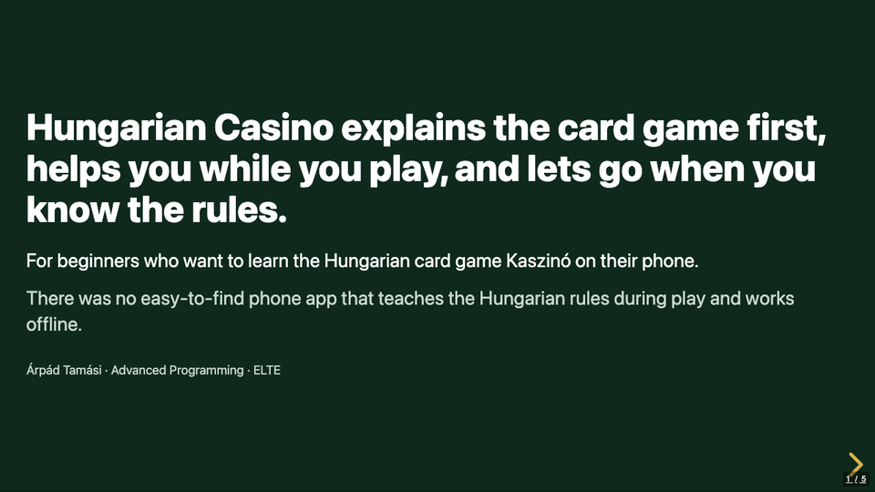

**First version**, built from the brief

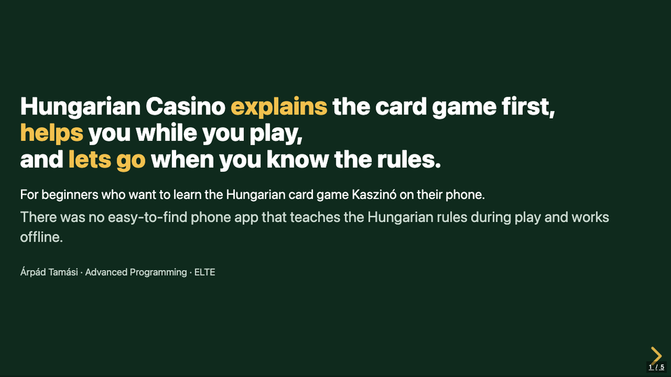

**After generate:** variant 1 of 3

The words did not change. What changed: which three words you remember.

## What will trip you up

- **Impeccable’s detector refuses overused fonts** (Fraunces, Inter, Roboto …). Let it.
- **`generate` happens in your browser:** keep the page open, and pick there.

## Before you publish

**GitHub Pages publishes everything in the folder,** to anyone, and the repository must be public.

- No personal data: bank statements, photos of faces, real names.
- Deleting a file is not enough: it stays in the git history.
- If something got in, ask me. Rewriting history is possible, but it is a separate job.

GitHub Docs: “Removing sensitive data from a repository”.

# Your video

## 30 seconds: your sentence, moving

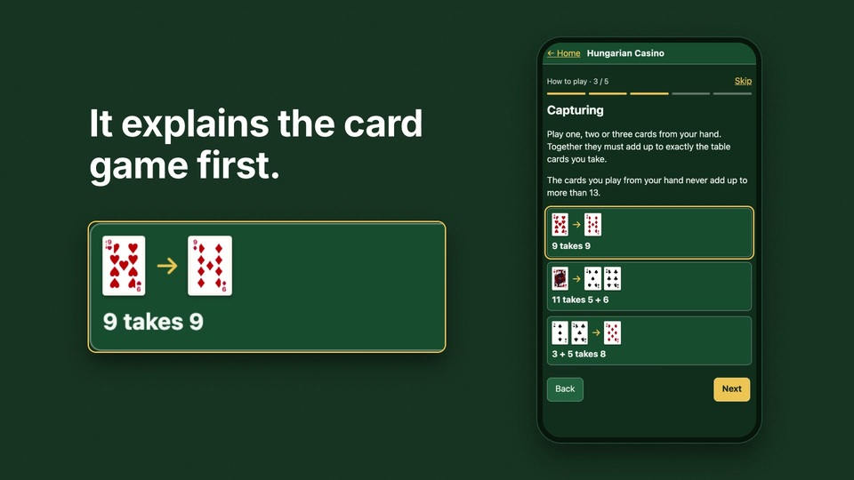

- **Three beats,** one for each part of your sentence.
- **Real screens** from your program.
- **No sound** needed. One line of text at a time.
- It lives on your page, **not in your presentation**.

## Making it

**Open Claude Code and say:**

> *Install HyperFrames from github.com/heygen-com/hyperframes. Then make a 30-second promo video from my promo page.*

It needs Node 22+ and FFmpeg. If it won’t start: record your screen, and add captions.

github.com/heygen-com/hyperframes, README. Cassino video: hyperframes 0.9.26.

# Your demo day

## 1 and 8 December

Five minutes each. A presentation, not a live run.

Everyone else in the room is your audience.

**Come to both days.**

“The second half of the semester”, Canvas announcement, 18 October 2026.

## Five minutes, five slides

|  | Slide |
| --- | --- |
| 1 | Who it is for, and why |
| 2 | Your demo: what goes in, what comes out — screenshots from a real run |
| 3 | Why it works: one check you did yourself — a test, a known answer, or a refusal |
| 4 | What you learned |
| 5 | What’s next: where you would take it from here |

One minute per slide. No title slide: your name goes on the first one.

## Slide 4: what you learned

#### Choose one

- **A.** One moment the agent got it wrong, and how you noticed.
- **B.** One decision the agent could not make for you.
- **C.** What you would do differently in your next project.

#### Make it concrete

- One moment, from your own repository.
- A commit, a test, a log entry, a change request: something I can open.

## The rules for your slides

- **Every screenshot from a real run** of your program. An illustration is labelled as one.
- **Every number has a source:** a run, a file, a test.
- **No speaker notes in the published deck:** on GitHub Pages anyone can read them in the page source.
- **It opens from one address.** We project from one shared computer, and I link every deck from esst-prog2.github.io.

## Where your slides go

**One address for everyone:**

esst-prog2.github.io/*your-repo*/slides/

| Your page is published | Put your slides in |
| --- | --- |
| from the `/docs` folder | `docs/slides/index.html` |
| from the root of `main` | `slides/index.html` |
| by a GitHub Actions build (Vite, …) | the folder it copies as it is, e.g. `public/slides/index.html` |

## reveal.js: slides are a web page

**Open Claude Code and say:**

> *Make my five slides with reveal.js, in one HTML file, in the slides folder of my GitHub Pages site, so that they open at esst-prog2.github.io/my-repo/slides/.*

**When you present:** → next · **S** speaker view · **O** overview · **F** full screen.

revealjs.com

## Live: the Cassino deck

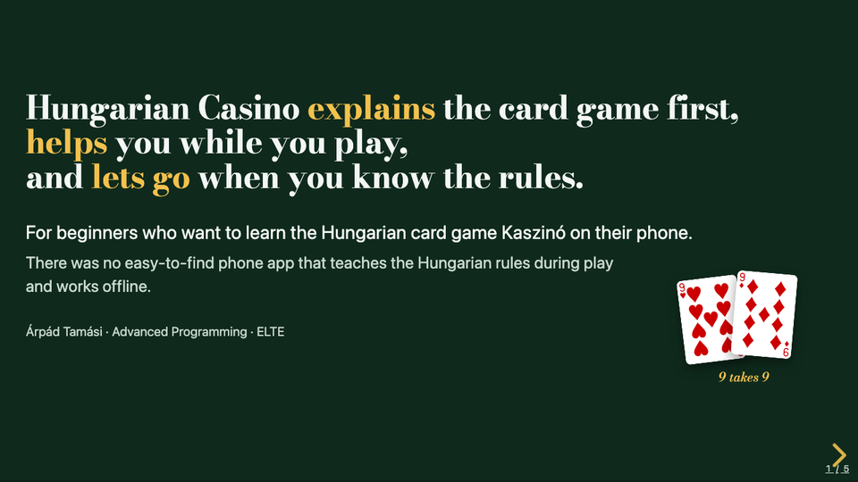

- Five slides at **esst-prog2.github.io/cassino/slides/**, the same pattern as yours.
- Slide 5: what’s next.
- **O** for the overview, **S** for the speaker view.

# Homework

## Homework 9 — Your page

1. **The content:** work it out with gstack’s `/office-hours`.
2. **The look, with Impeccable:** `shape`, `generate`, `critique` (as a classmate, your teacher, a stranger).
3. **On GitHub Pages:** a promo page. If your program runs online, a link to it.
4. **A `PROCESS.md`,** one commit per step.
5. Paste on Canvas: the address of your page.

Due **Saturday 14 November, 20:00**.

## Homework 10 — Your video

1. **About 30 seconds,** made with HyperFrames, or a screen recording with captions.
2. **On your page.**
3. Paste on Canvas: the address of your page.

Due **Saturday 21 November, 20:00**.

## The dates

| **14 November** | your page |
| --- | --- |
| 17 November | next class |
| **21 November** | your video |
| 24 November | last class |
| **28 November** | your slides in your repository |
| **1 and 8 December** | the demos: come to both |